# Chapter 2, Exercise 8

### (a)

```r
college = read.csv("C:/Users/Daniel Choi/git/comp_labs/COMP4432/HW1/College.csv")
```

### (b)

```r
rownames(college) <- college[,1]
college <- college[,-1]
```

### (c)

```r
# i.
summary(college)
```

```
   Private               Apps           Accept          Enroll
 Length:777         Min.   :   81   Min.   :   72   Min.   :  35
 Class :character   1st Qu.:  776   1st Qu.:  604   1st Qu.: 242
 Mode  :character   Median : 1558   Median : 1110   Median : 434
                    Mean   : 3002   Mean   : 2019   Mean   : 780
                    3rd Qu.: 3624   3rd Qu.: 2424   3rd Qu.: 902
                    Max.   :48094   Max.   :26330   Max.   :6392
   Top10perc       Top25perc      F.Undergrad     P.Undergrad
 Min.   : 1.00   Min.   :  9.0   Min.   :  139   Min.   :    1.0
 1st Qu.:15.00   1st Qu.: 41.0   1st Qu.:  992   1st Qu.:   95.0
 Median :23.00   Median : 54.0   Median : 1707   Median :  353.0
 Mean   :27.56   Mean   : 55.8   Mean   : 3700   Mean   :  855.3
 3rd Qu.:35.00   3rd Qu.: 69.0   3rd Qu.: 4005   3rd Qu.:  967.0
 Max.   :96.00   Max.   :100.0   Max.   :31643   Max.   :21836.0
    Outstate       Room.Board       Books           Personal
 Min.   : 2340   Min.   :1780   Min.   :  96.0   Min.   : 250
 1st Qu.: 7320   1st Qu.:3597   1st Qu.: 470.0   1st Qu.: 850
 Median : 9990   Median :4200   Median : 500.0   Median :1200
 Mean   :10441   Mean   :4358   Mean   : 549.4   Mean   :1341
 3rd Qu.:12925   3rd Qu.:5050   3rd Qu.: 600.0   3rd Qu.:1700
 Max.   :21700   Max.   :8124   Max.   :2340.0   Max.   :6800
      PhD            Terminal       S.F.Ratio      perc.alumni
 Min.   :  8.00   Min.   : 24.0   Min.   : 2.50   Min.   : 0.00
 1st Qu.: 62.00   1st Qu.: 71.0   1st Qu.:11.50   1st Qu.:13.00
 Median : 75.00   Median : 82.0   Median :13.60   Median :21.00
 Mean   : 72.66   Mean   : 79.7   Mean   :14.09   Mean   :22.74
 3rd Qu.: 85.00   3rd Qu.: 92.0   3rd Qu.:16.50   3rd Qu.:31.00
 Max.   :103.00   Max.   :100.0   Max.   :39.80   Max.   :64.00
     Expend        Grad.Rate
 Min.   : 3186   Min.   : 10.00
 1st Qu.: 6751   1st Qu.: 53.00
 Median : 8377   Median : 65.00
 Mean   : 9660   Mean   : 65.46
 3rd Qu.:10830   3rd Qu.: 78.00
 Max.   :56233   Max.   :118.00
```

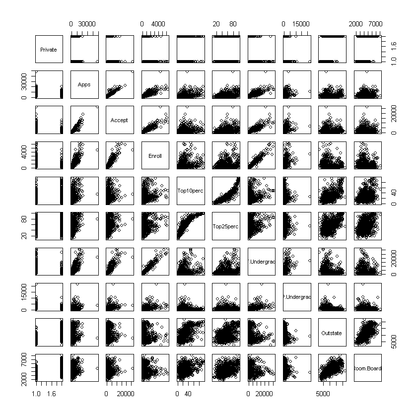

```r
# ii.
college$Private <- as.factor(college$Private)
pairs(college[,1:10])
```

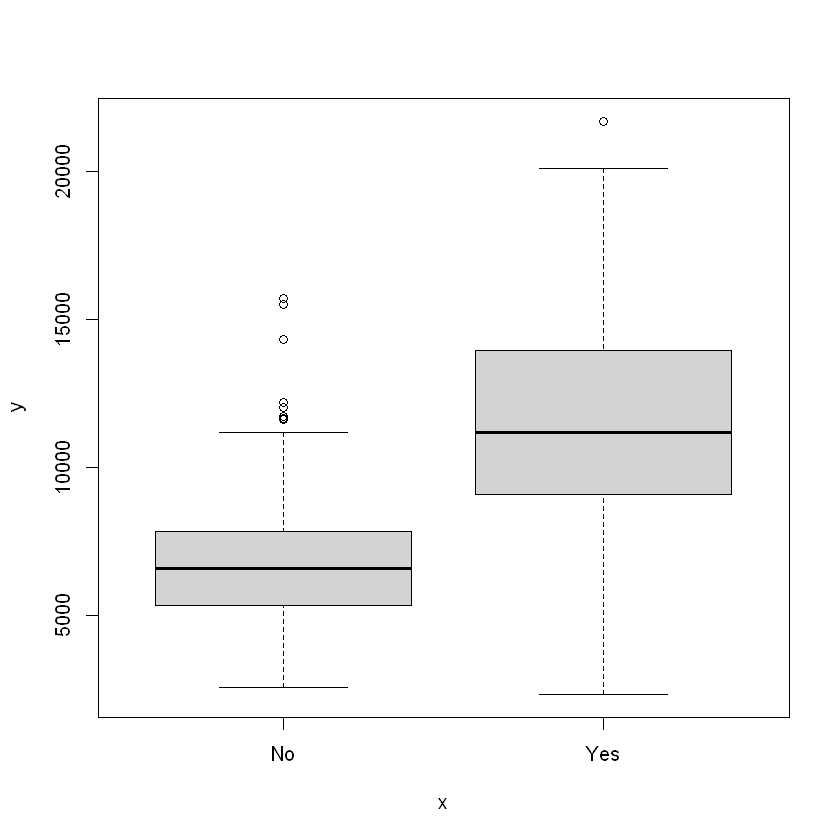

```r
# iii.
plot(college$Private, college$Outstate)
```

```
 Private        Apps           Accept          Enroll       Top10perc
 No :212   Min.   :   81   Min.   :   72   Min.   :  35   Min.   : 1.00
 Yes:565   1st Qu.:  776   1st Qu.:  604   1st Qu.: 242   1st Qu.:15.00
           Median : 1558   Median : 1110   Median : 434   Median :23.00
           Mean   : 3002   Mean   : 2019   Mean   : 780   Mean   :27.56
           3rd Qu.: 3624   3rd Qu.: 2424   3rd Qu.: 902   3rd Qu.:35.00
           Max.   :48094   Max.   :26330   Max.   :6392   Max.   :96.00
   Top25perc      F.Undergrad     P.Undergrad         Outstate
 Min.   :  9.0   Min.   :  139   Min.   :    1.0   Min.   : 2340
 1st Qu.: 41.0   1st Qu.:  992   1st Qu.:   95.0   1st Qu.: 7320
 Median : 54.0   Median : 1707   Median :  353.0   Median : 9990
 Mean   : 55.8   Mean   : 3700   Mean   :  855.3   Mean   :10441
 3rd Qu.: 69.0   3rd Qu.: 4005   3rd Qu.:  967.0   3rd Qu.:12925
 Max.   :100.0   Max.   :31643   Max.   :21836.0   Max.   :21700
   Room.Board       Books           Personal         PhD
 Min.   :1780   Min.   :  96.0   Min.   : 250   Min.   :  8.00
 1st Qu.:3597   1st Qu.: 470.0   1st Qu.: 850   1st Qu.: 62.00
 Median :4200   Median : 500.0   Median :1200   Median : 75.00
 Mean   :4358   Mean   : 549.4   Mean   :1341   Mean   : 72.66
 3rd Qu.:5050   3rd Qu.: 600.0   3rd Qu.:1700   3rd Qu.: 85.00
 Max.   :8124   Max.   :2340.0   Max.   :6800   Max.   :103.00
    Terminal       S.F.Ratio      perc.alumni        Expend
 Min.   : 24.0   Min.   : 2.50   Min.   : 0.00   Min.   : 3186
 1st Qu.: 71.0   1st Qu.:11.50   1st Qu.:13.00   1st Qu.: 6751
 Median : 82.0   Median :13.60   Median :21.00   Median : 8377
 Mean   : 79.7   Mean   :14.09   Mean   :22.74   Mean   : 9660
 3rd Qu.: 92.0   3rd Qu.:16.50   3rd Qu.:31.00   3rd Qu.:10830
 Max.   :100.0   Max.   :39.80   Max.   :64.00   Max.   :56233
   Grad.Rate        Elite
 Min.   : 10.00    Yes : 78
 1st Qu.: 53.00   No   :699
 Median : 65.00
 Mean   : 65.46
 3rd Qu.: 78.00
 Max.   :118.00
```

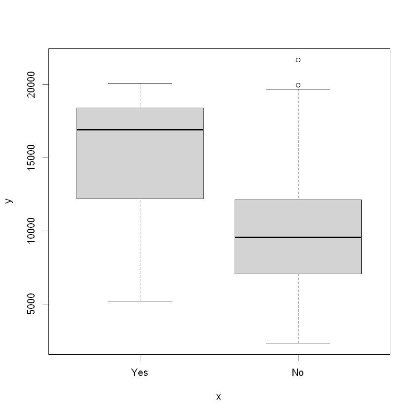

```r
# iv.
Elite <- rep ("No", nrow (college))
Elite[college$Top10perc > 50] <- " Yes "
Elite <- as.factor(Elite)
college <- data.frame(college , Elite)

summary(college)
plot(college$Elite, college$Outstate)
```

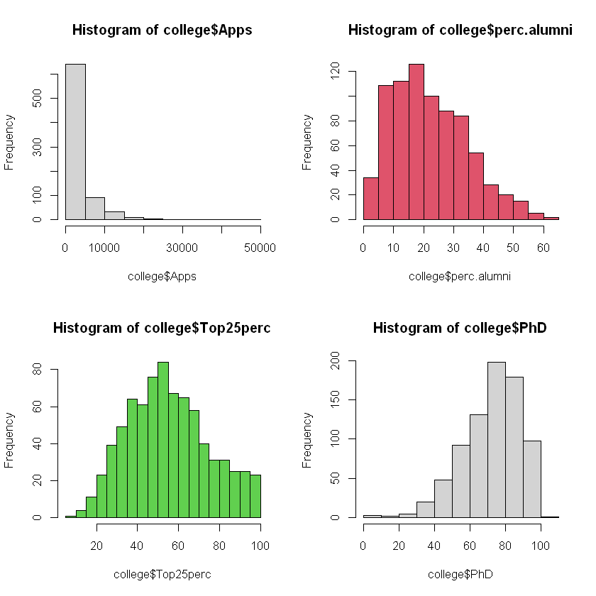

```r
# v.
par(mfrow = c(2, 2))
hist(college$Apps)
hist(college$perc.alumni, col=2)
hist(college$Top25perc, col=3, breaks=30)
hist(college$PhD, breaks=10)
```

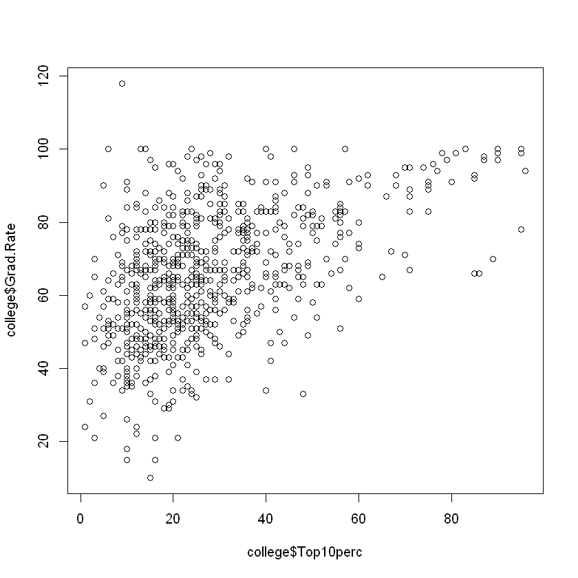

```r
# vi.

# Graduation rate greater than 100% is an error data
# Top highschoolers do not always graduate
plot(college$Top10perc, college$Grad.Rate)
```

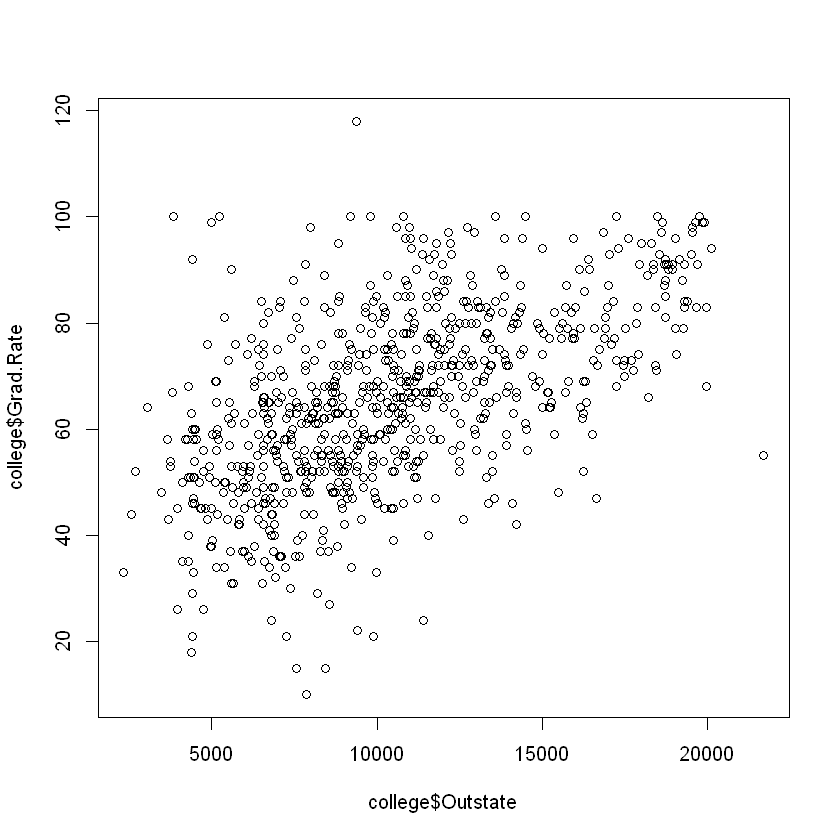

```r
# Students with high tution is more likely to graduate.
plot(college$Outstate, college$Grad.Rate)
```

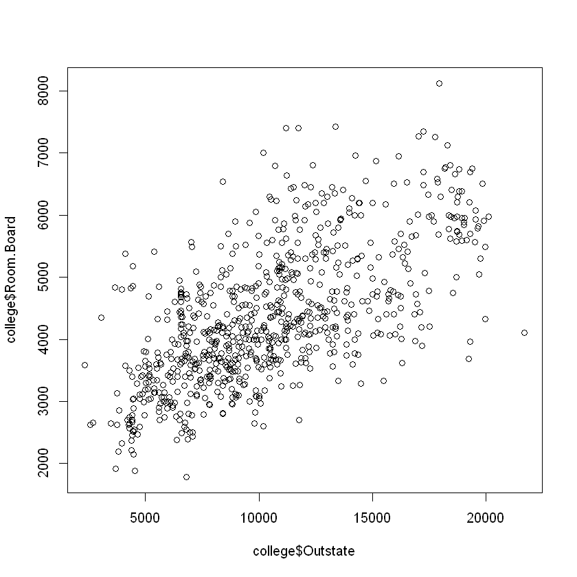

```r
# Out-of-tution fee correlates with Room.Board
plot(college$Outstate, college$Room.Board)
```

# Chapter 2, Exercise 10

```r
library (ISLR2)
Boston
```

```r
?Boston
```

### (a)

There are 13 features and 506 records related to housing in Boston

```r
# 506 rows, 13 columns
dim(Boston)
```

1. 506

2. 13

### (b)

1. crim correlates with age, dis
2. zn correlates with age, lstat
3. nox correlates with age, dis
4. lstat correlates with medv

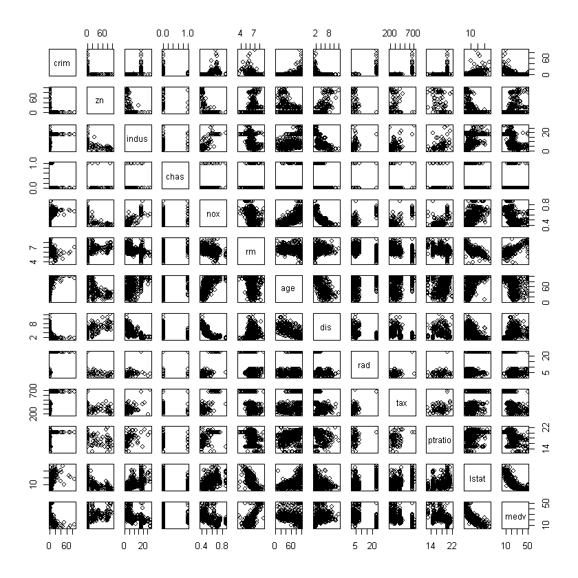

```r
pairs(Boston)
```

### (c)

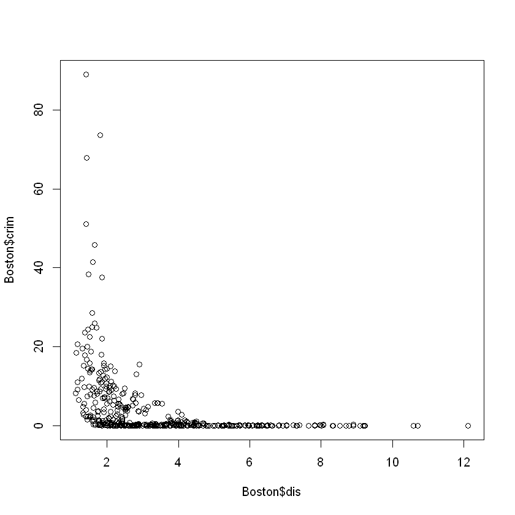

```r
plot(Boston$dis, Boston$crim)
```

If house is closer to workplaces, more likely crime to happen

### (d)

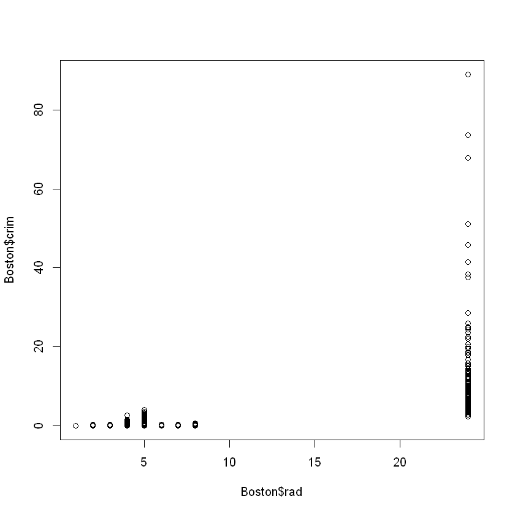

```r
plot(Boston$rad, Boston$crim)
```

Higher accessibility to highways, more likely crime to happen

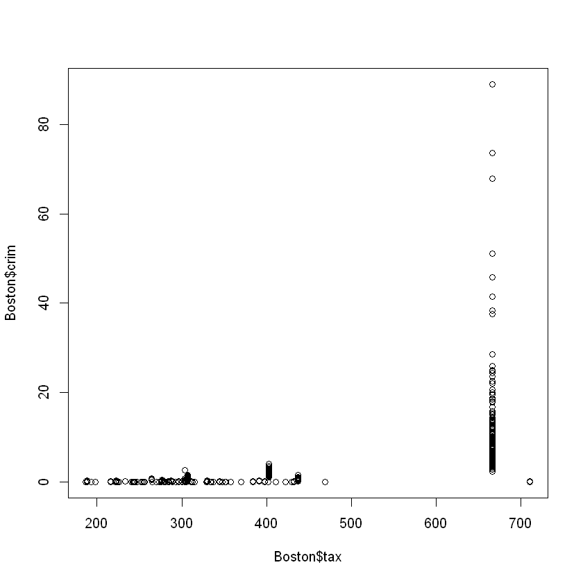

```r
plot(Boston$tax, Boston$crim)
```

Higher tax rate indicates higher crime rate

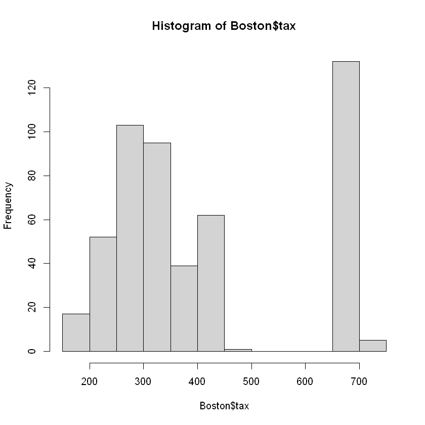

```r
hist(Boston$tax, breaks=10)
```

There is a large separation in tax rates between 200-450 zone and 650-750 zone.

### (e)

35

```r
dim(subset(Boston, chas == 1))
```

1. 35

2. 13

### (f)

19.05

```r
median(Boston$ptratio)
```

19.05

### (g)

crim: Above 3rd quartile  
zn: Min  
indus: At 3rd quartile  
chas: Not bounded by the river  
nox: above 3rd quartile  
rm: below 1st quartile  
age: at max  
...

Not a good place to live, but not that bad

```r
subset(Boston, medv == min(Boston$medv))
summary(Boston)
```

A data.frame: 2 × 13

|  | crim <dbl> | zn <dbl> | indus <dbl> | chas <int> | nox <dbl> | rm <dbl> | age <dbl> | dis <dbl> | rad <int> | tax <dbl> | ptratio <dbl> | lstat <dbl> | medv <dbl> |
| --- | --- | --- | --- | --- | --- | --- | --- | --- | --- | --- | --- | --- | --- |
| 399 | 38.3518 | 0 | 18.1 | 0 | 0.693 | 5.453 | 100 | 1.4896 | 24 | 666 | 20.2 | 30.59 | 5 |
| 406 | 67.9208 | 0 | 18.1 | 0 | 0.693 | 5.683 | 100 | 1.4254 | 24 | 666 | 20.2 | 22.98 | 5 |

```
      crim                zn             indus            chas
 Min.   : 0.00632   Min.   :  0.00   Min.   : 0.46   Min.   :0.00000
 1st Qu.: 0.08205   1st Qu.:  0.00   1st Qu.: 5.19   1st Qu.:0.00000
 Median : 0.25651   Median :  0.00   Median : 9.69   Median :0.00000
 Mean   : 3.61352   Mean   : 11.36   Mean   :11.14   Mean   :0.06917
 3rd Qu.: 3.67708   3rd Qu.: 12.50   3rd Qu.:18.10   3rd Qu.:0.00000
 Max.   :88.97620   Max.   :100.00   Max.   :27.74   Max.   :1.00000
      nox               rm             age              dis
 Min.   :0.3850   Min.   :3.561   Min.   :  2.90   Min.   : 1.130
 1st Qu.:0.4490   1st Qu.:5.886   1st Qu.: 45.02   1st Qu.: 2.100
 Median :0.5380   Median :6.208   Median : 77.50   Median : 3.207
 Mean   :0.5547   Mean   :6.285   Mean   : 68.57   Mean   : 3.795
 3rd Qu.:0.6240   3rd Qu.:6.623   3rd Qu.: 94.08   3rd Qu.: 5.188
 Max.   :0.8710   Max.   :8.780   Max.   :100.00   Max.   :12.127
      rad              tax           ptratio          lstat
 Min.   : 1.000   Min.   :187.0   Min.   :12.60   Min.   : 1.73
 1st Qu.: 4.000   1st Qu.:279.0   1st Qu.:17.40   1st Qu.: 6.95
 Median : 5.000   Median :330.0   Median :19.05   Median :11.36
 Mean   : 9.549   Mean   :408.2   Mean   :18.46   Mean   :12.65
 3rd Qu.:24.000   3rd Qu.:666.0   3rd Qu.:20.20   3rd Qu.:16.95
 Max.   :24.000   Max.   :711.0   Max.   :22.00   Max.   :37.97
      medv
 Min.   : 5.00
 1st Qu.:17.02
 Median :21.20
 Mean   :22.53
 3rd Qu.:25.00
 Max.   :50.00
```

### (h)

7 rooms per dwelling: 64  
8 rooms per dwelling: 13  
Comment: crim and lstat is much lower than average

```r
rm7 <- subset(Boston, rm > 7)
dim(rm7)

rm8 <- subset(Boston, rm > 8)
dim(rm8)
```

1. 64

2. 13

1. 13

2. 13

```r
summary(rm8)
```

```
      crim               zn            indus             chas
 Min.   :0.02009   Min.   : 0.00   Min.   : 2.680   Min.   :0.0000
 1st Qu.:0.33147   1st Qu.: 0.00   1st Qu.: 3.970   1st Qu.:0.0000
 Median :0.52014   Median : 0.00   Median : 6.200   Median :0.0000
 Mean   :0.71879   Mean   :13.62   Mean   : 7.078   Mean   :0.1538
 3rd Qu.:0.57834   3rd Qu.:20.00   3rd Qu.: 6.200   3rd Qu.:0.0000
 Max.   :3.47428   Max.   :95.00   Max.   :19.580   Max.   :1.0000
      nox               rm             age             dis
 Min.   :0.4161   Min.   :8.034   Min.   : 8.40   Min.   :1.801
 1st Qu.:0.5040   1st Qu.:8.247   1st Qu.:70.40   1st Qu.:2.288
 Median :0.5070   Median :8.297   Median :78.30   Median :2.894
 Mean   :0.5392   Mean   :8.349   Mean   :71.54   Mean   :3.430
 3rd Qu.:0.6050   3rd Qu.:8.398   3rd Qu.:86.50   3rd Qu.:3.652
 Max.   :0.7180   Max.   :8.780   Max.   :93.90   Max.   :8.907
      rad              tax           ptratio          lstat           medv
 Min.   : 2.000   Min.   :224.0   Min.   :13.00   Min.   :2.47   Min.   :21.9
 1st Qu.: 5.000   1st Qu.:264.0   1st Qu.:14.70   1st Qu.:3.32   1st Qu.:41.7
 Median : 7.000   Median :307.0   Median :17.40   Median :4.14   Median :48.3
 Mean   : 7.462   Mean   :325.1   Mean   :16.36   Mean   :4.31   Mean   :44.2
 3rd Qu.: 8.000   3rd Qu.:307.0   3rd Qu.:17.40   3rd Qu.:5.12   3rd Qu.:50.0
 Max.   :24.000   Max.   :666.0   Max.   :20.20   Max.   :7.44   Max.   :50.0
```

# Chapter 3, Exercise 8

```r
Auto = read.csv("C:/Users/Daniel Choi/git/comp_labs/COMP4432/HW1/Auto.csv", header=T, na.strings="?")
Auto = na.omit(Auto)
summary(Auto)
```

```
      mpg          cylinders      displacement     horsepower        weight
 Min.   : 9.00   Min.   :3.000   Min.   : 68.0   Min.   : 46.0   Min.   :1613
 1st Qu.:17.00   1st Qu.:4.000   1st Qu.:105.0   1st Qu.: 75.0   1st Qu.:2225
 Median :22.75   Median :4.000   Median :151.0   Median : 93.5   Median :2804
 Mean   :23.45   Mean   :5.472   Mean   :194.4   Mean   :104.5   Mean   :2978
 3rd Qu.:29.00   3rd Qu.:8.000   3rd Qu.:275.8   3rd Qu.:126.0   3rd Qu.:3615
 Max.   :46.60   Max.   :8.000   Max.   :455.0   Max.   :230.0   Max.   :5140
  acceleration        year           origin          name
 Min.   : 8.00   Min.   :70.00   Min.   :1.000   Length:392
 1st Qu.:13.78   1st Qu.:73.00   1st Qu.:1.000   Class :character
 Median :15.50   Median :76.00   Median :1.000   Mode  :character
 Mean   :15.54   Mean   :75.98   Mean   :1.577
 3rd Qu.:17.02   3rd Qu.:79.00   3rd Qu.:2.000
 Max.   :24.80   Max.   :82.00   Max.   :3.000
```

### (a)

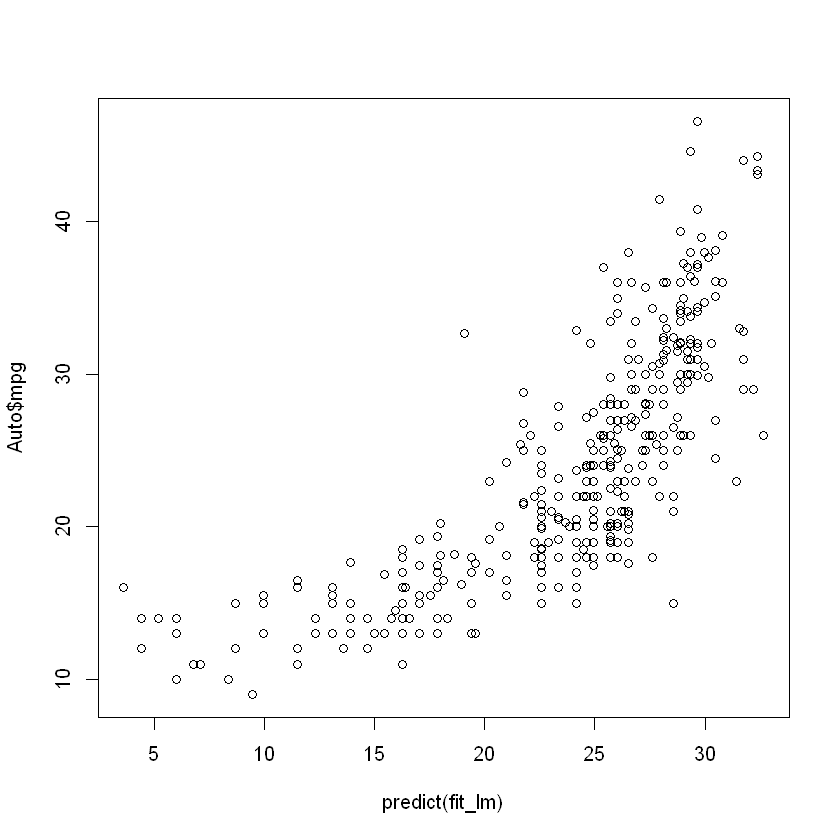

```r
fit_lm = lm(mpg ~ horsepower, data=Auto)
plot(x=predict(fit_lm), y=Auto$mpg)
```

```r
summary(fit_lm)
```

```
Call:
lm(formula = mpg ~ horsepower, data = Auto)

Residuals:
     Min       1Q   Median       3Q      Max
-13.5710  -3.2592  -0.3435   2.7630  16.9240

Coefficients:
             Estimate Std. Error t value Pr(>|t|)
(Intercept) 39.935861   0.717499   55.66   <2e-16 ***
horsepower  -0.157845   0.006446  -24.49   <2e-16 ***
---
Signif. codes:  0 '***' 0.001 '**' 0.01 '*' 0.05 '.' 0.1 ' ' 1

Residual standard error: 4.906 on 390 degrees of freedom
Multiple R-squared:  0.6059,	Adjusted R-squared:  0.6049
F-statistic: 599.7 on 1 and 390 DF,  p-value: < 2.2e-16
```

i. Yes. `mpg` and `housepower` have correlation. Since p-value is very small there is a strong evidence to believe that `horsepower` is associated with `mpg`

ii. $ R^2 $ value suggests the percentage of the variance of response explained by the predictor. Their relationship is 61% strong.

```r
summary(fit_lm)$r.squared
```

0.605948257889435

iii. The relationship between mpg and horsepower is negative

```r
coefficients(fit_lm)
```

**(Intercept)**

39.9358610211705

**horsepower**

-0.157844733353654

iv.

```r
predict(fit_lm, data.frame(horsepower=c(98)), interval="confidence", level=0.95)
```

A matrix: 1 × 3 of type dbl

|  | fit | lwr | upr |
| --- | --- | --- | --- |
| 1 | 24.46708 | 23.97308 | 24.96108 |

```r
predict(fit_lm, data.frame(horsepower=c(98)), interval="prediction", level=0.95)
```

A matrix: 1 × 3 of type dbl

|  | fit | lwr | upr |
| --- | --- | --- | --- |
| 1 | 24.46708 | 14.8094 | 34.12476 |

### (b)

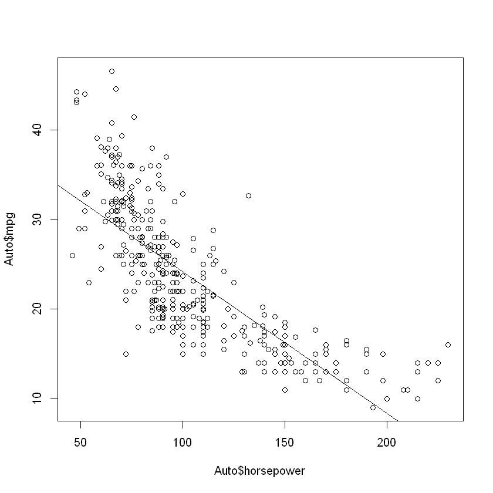

```r
plot(x=Auto$horsepower, y=Auto$mpg)
abline(fit_lm)
```

### (c)

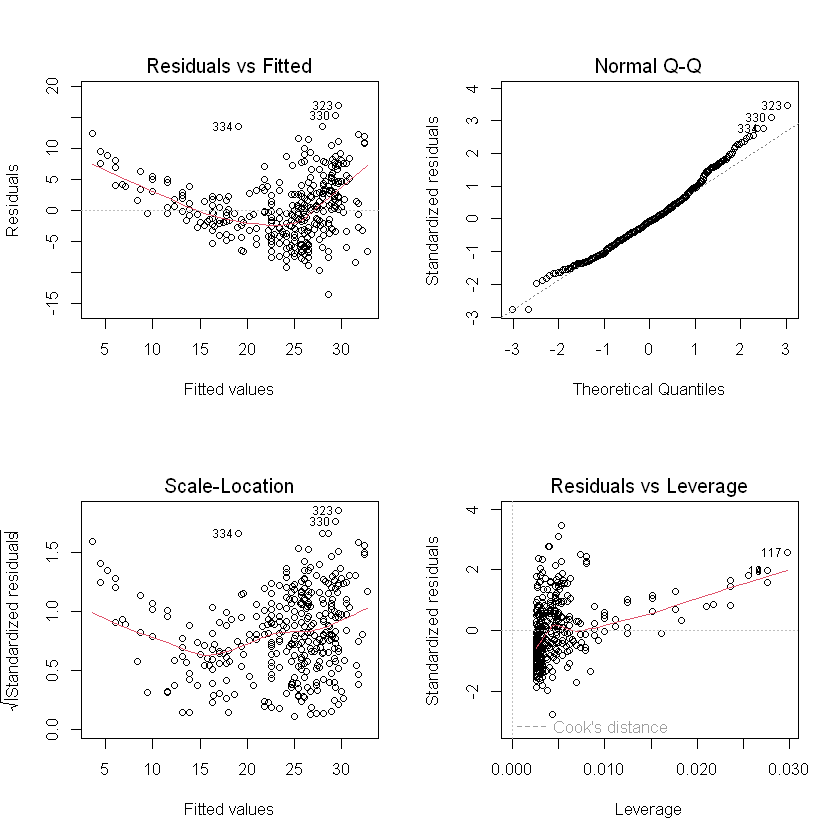

```r
par(mfrow=c(2,2))
plot(fit_lm)
```

1. Residuals-Fitted graph shows a pattern. This indicates the presence of non-linearity in the relationship between predictors and response
2. Scale-Location graph, there are posible outliers

# Chapter 3, Exercise 9

```r
Auto = read.csv("C:/Users/Daniel Choi/git/comp_labs/COMP4432/HW1/Auto.csv", header=T, na.strings="?")
Auto = na.omit(Auto)
```

### (a)

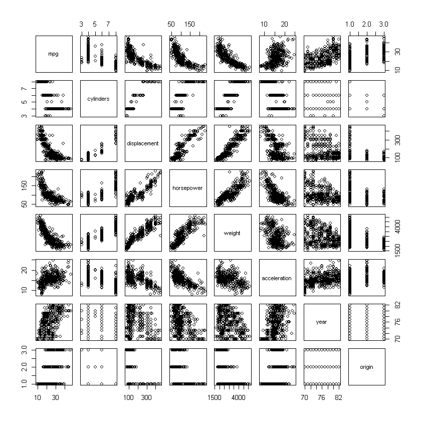

```r
pairs(Auto[1:8])
```

### (b)

```r
cor(Auto[-9])
```

A matrix: 8 × 8 of type dbl

|  | mpg | cylinders | displacement | horsepower | weight | acceleration | year | origin |
| --- | --- | --- | --- | --- | --- | --- | --- | --- |
| mpg | 1.0000000 | -0.7776175 | -0.8051269 | -0.7784268 | -0.8322442 | 0.4233285 | 0.5805410 | 0.5652088 |
| cylinders | -0.7776175 | 1.0000000 | 0.9508233 | 0.8429834 | 0.8975273 | -0.5046834 | -0.3456474 | -0.5689316 |
| displacement | -0.8051269 | 0.9508233 | 1.0000000 | 0.8972570 | 0.9329944 | -0.5438005 | -0.3698552 | -0.6145351 |
| horsepower | -0.7784268 | 0.8429834 | 0.8972570 | 1.0000000 | 0.8645377 | -0.6891955 | -0.4163615 | -0.4551715 |
| weight | -0.8322442 | 0.8975273 | 0.9329944 | 0.8645377 | 1.0000000 | -0.4168392 | -0.3091199 | -0.5850054 |
| acceleration | 0.4233285 | -0.5046834 | -0.5438005 | -0.6891955 | -0.4168392 | 1.0000000 | 0.2903161 | 0.2127458 |
| year | 0.5805410 | -0.3456474 | -0.3698552 | -0.4163615 | -0.3091199 | 0.2903161 | 1.0000000 | 0.1815277 |
| origin | 0.5652088 | -0.5689316 | -0.6145351 | -0.4551715 | -0.5850054 | 0.2127458 | 0.1815277 | 1.0000000 |

### (c)

```r
yhat_lm = lm(mpg~.-name, data=Auto)
summary(yhat_lm)
```

```
Call:
lm(formula = mpg ~ . - name, data = Auto)

Residuals:
    Min      1Q  Median      3Q     Max
-9.5903 -2.1565 -0.1169  1.8690 13.0604

Coefficients:
               Estimate Std. Error t value Pr(>|t|)
(Intercept)  -17.218435   4.644294  -3.707  0.00024 ***
cylinders     -0.493376   0.323282  -1.526  0.12780
displacement   0.019896   0.007515   2.647  0.00844 **
horsepower    -0.016951   0.013787  -1.230  0.21963
weight        -0.006474   0.000652  -9.929  < 2e-16 ***
acceleration   0.080576   0.098845   0.815  0.41548
year           0.750773   0.050973  14.729  < 2e-16 ***
origin         1.426141   0.278136   5.127 4.67e-07 ***
---
Signif. codes:  0 '***' 0.001 '**' 0.01 '*' 0.05 '.' 0.1 ' ' 1

Residual standard error: 3.328 on 384 degrees of freedom
Multiple R-squared:  0.8215,	Adjusted R-squared:  0.8182
F-statistic: 252.4 on 7 and 384 DF,  p-value: < 2.2e-16
```

```r
coef(yhat_lm)["year"]
```

**year:** 0.750772677950312

i. Since p-value is very small there is a strong evidence to believe that there is a relationship between predictors and `mpg`

ii. predictors except `cylinders`, `horsepower`, and `acceration`, have significant relationship to the response.

iii. coefficient of `year` (i.e. 0.75) indicates that the rate of increase in mpg every year

### (d)

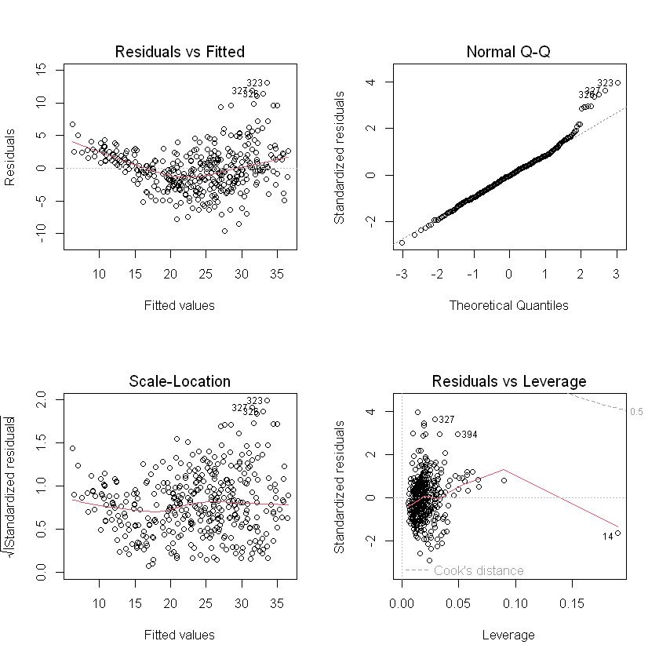

```r
par(mfrow=c(2,2))
plot(yhat_lm)
```

1. Residuals-Fitted graph indicates the presence of non-linearity in the relationship between predictors and response

[figure not shown]

```r
plot(predict(yhat_lm), rstudent(yhat_lm))
abline(h=3, col="blue", lty=2)
```

1. In rstudent residual-Fitted value graph, there are 4 rstudentized residuals (> 3) which indicates the potential outliers.

### (e)

```r
lm_asterisk <- lm(formula = mpg ~ . * ., data = Auto[, -9])
```

```r
summary(lm_asterisk)
```

```
Call:
lm(formula = mpg ~ . * ., data = Auto[, -9])

Residuals:
    Min      1Q  Median      3Q     Max
-7.6303 -1.4481  0.0596  1.2739 11.1386

Coefficients:
                            Estimate Std. Error t value Pr(>|t|)
(Intercept)                3.548e+01  5.314e+01   0.668  0.50475
cylinders                  6.989e+00  8.248e+00   0.847  0.39738
displacement              -4.785e-01  1.894e-01  -2.527  0.01192 *
horsepower                 5.034e-01  3.470e-01   1.451  0.14769
weight                     4.133e-03  1.759e-02   0.235  0.81442
acceleration              -5.859e+00  2.174e+00  -2.696  0.00735 **
year                       6.974e-01  6.097e-01   1.144  0.25340
origin                    -2.090e+01  7.097e+00  -2.944  0.00345 **
cylinders:displacement    -3.383e-03  6.455e-03  -0.524  0.60051
cylinders:horsepower       1.161e-02  2.420e-02   0.480  0.63157
cylinders:weight           3.575e-04  8.955e-04   0.399  0.69000
cylinders:acceleration     2.779e-01  1.664e-01   1.670  0.09584 .
cylinders:year            -1.741e-01  9.714e-02  -1.793  0.07389 .
cylinders:origin           4.022e-01  4.926e-01   0.816  0.41482
displacement:horsepower   -8.491e-05  2.885e-04  -0.294  0.76867
displacement:weight        2.472e-05  1.470e-05   1.682  0.09342 .
displacement:acceleration -3.479e-03  3.342e-03  -1.041  0.29853
displacement:year          5.934e-03  2.391e-03   2.482  0.01352 *
displacement:origin        2.398e-02  1.947e-02   1.232  0.21875
horsepower:weight         -1.968e-05  2.924e-05  -0.673  0.50124
horsepower:acceleration   -7.213e-03  3.719e-03  -1.939  0.05325 .
horsepower:year           -5.838e-03  3.938e-03  -1.482  0.13916
horsepower:origin          2.233e-03  2.930e-02   0.076  0.93931
weight:acceleration        2.346e-04  2.289e-04   1.025  0.30596
weight:year               -2.245e-04  2.127e-04  -1.056  0.29182
weight:origin             -5.789e-04  1.591e-03  -0.364  0.71623
acceleration:year          5.562e-02  2.558e-02   2.174  0.03033 *
acceleration:origin        4.583e-01  1.567e-01   2.926  0.00365 **
year:origin                1.393e-01  7.399e-02   1.882  0.06062 .
---
Signif. codes:  0 '***' 0.001 '**' 0.01 '*' 0.05 '.' 0.1 ' ' 1

Residual standard error: 2.695 on 363 degrees of freedom
Multiple R-squared:  0.8893,	Adjusted R-squared:  0.8808
F-statistic: 104.2 on 28 and 363 DF,  p-value: < 2.2e-16
```

Following interactions are statistically significant:

1. displacement:year
2. acceleration:year
3. acceleration:origin

### (f)

From (a), we can observe that displacement, horsepower and weight follow logarithmic form.

```r
lm_transform <- lm(formula = log(mpg) ~ ., data = Auto[, -9])
summary(lm_transform)
```

```
Call:
lm(formula = log(mpg) ~ ., data = Auto[, -9])

Residuals:
     Min       1Q   Median       3Q      Max
-0.40955 -0.06533  0.00079  0.06785  0.33925

Coefficients:
               Estimate Std. Error t value Pr(>|t|)
(Intercept)   1.751e+00  1.662e-01  10.533  < 2e-16 ***
cylinders    -2.795e-02  1.157e-02  -2.415  0.01619 *
displacement  6.362e-04  2.690e-04   2.365  0.01852 *
horsepower   -1.475e-03  4.935e-04  -2.989  0.00298 **
weight       -2.551e-04  2.334e-05 -10.931  < 2e-16 ***
acceleration -1.348e-03  3.538e-03  -0.381  0.70339
year          2.958e-02  1.824e-03  16.211  < 2e-16 ***
origin        4.071e-02  9.955e-03   4.089 5.28e-05 ***
---
Signif. codes:  0 '***' 0.001 '**' 0.01 '*' 0.05 '.' 0.1 ' ' 1

Residual standard error: 0.1191 on 384 degrees of freedom
Multiple R-squared:  0.8795,	Adjusted R-squared:  0.8773
F-statistic: 400.4 on 7 and 384 DF,  p-value: < 2.2e-16
```

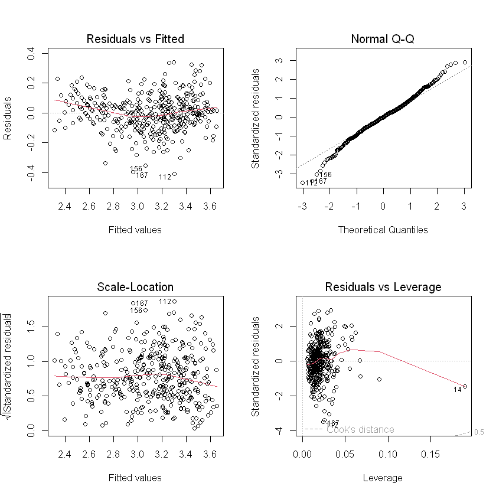

```r
par(mfrow=c(2,2))
plot(lm_transform)
```

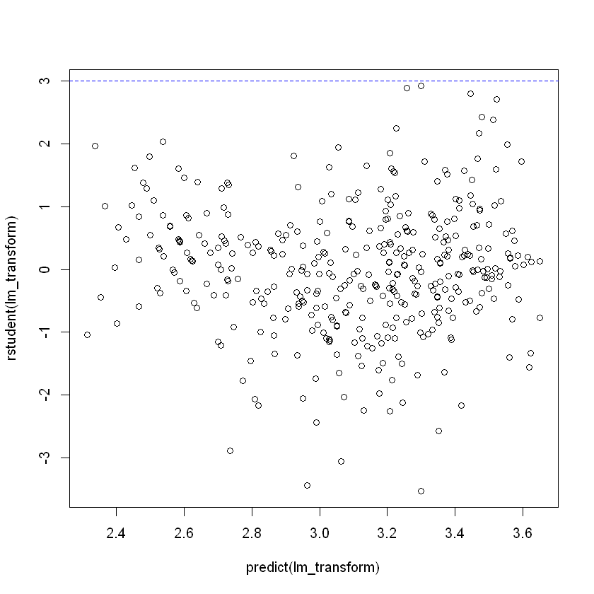

```r
plot(predict(lm_transform), rstudent(lm_transform))
abline(h=3, col="blue", lty=2)
```

# Additional Coding Part

```r
library(FNN)
library(ggplot2)

rm(list=ls())
ntrain <- 50 # Training
ntest <- 500 # Testing
nrep <- 100 # repeat 100 times
p <- 20
puse <- c(1, 2, 3, 4, 10, 20) # number of predictors
k <- c(1:9)

sigma <- 0.025

Xtrain <- matrix(runif(ntrain * p, -1, 1), ntrain, p)
Xtest <- matrix(runif(ntest * p, -1, 1), ntest, p)
y0 <- sin(2 * Xtrain[, 1]) # Only the first predictor is related to y
ytest <- sin(2 *  Xtest[, 1])

out_knn <- data.frame() # Output results
out_lm <- data.frame()
```

```r
for(i in 1:length(puse)){
  yhat_lm <- matrix(0, ntest, nrep)
  yhat_knn <- replicate(length(k), matrix(0, ntest, nrep))

  for(l in 1:nrep){
    df_train <- data.frame(x=Xtrain[,1:puse[i]])
    y <- y0 + rnorm(ntrain, 0, sigma)

    ######### DO: fit linear regression using lm funciton, assign predicted value to yhat_lm[,l] #########
    fit_lm <- lm(y ~ ., data = df_train)
    testdata = data.frame(x=Xtest[, 1:puse[i]])
    yhat_lm[, l] <- predict(fit_lm, newdata=testdata) # Predicted value by lm

    for(j in 1:length(k)){
      ######### DO: fit knn using knn.reg funciton, assign predicted value to yhat_knn[, l, j] #########
      fit_knn <- knn.reg(
        train = df_train,
        y = y,
        test = testdata,
        k = j,
      )
      yhat_knn[, l, j] <- fit_knn$pred # Predicted value by knn.reg
    }
  #  cat(i, "-th p, ", l, "-th repitition finished. \n")
  }

  ######### DO: compute bias and variance of linear regression #########

  # Compute mean of predicted values
  ybar_lm <- rowMeans(yhat_lm) # E(f^hat)

  # Compute bias^2
  biasSQ_lm <- mean((ytest - ybar_lm)^2) # E[ (f - E(f^hat))^2 ]

  # Compute variance
  variance_lm <- mean((ybar_lm - yhat_lm)^2)# E[ (E(f^hat) - f^hat)^2 ]

  # Compute total MSE
  err_lm <- biasSQ_lm + variance_lm
  #
  out_lm <- rbind(out_lm, data.frame(error = biasSQ_lm, component = "squared-bias", p = paste0("p = ", puse[i])))
  out_lm <- rbind(out_lm, data.frame(error = variance_lm, component = "variance", p = paste0("p = ", puse[i])))
  out_lm <- rbind(out_lm, data.frame(error = err_lm, component = "MSE", p = paste0("p = ", puse[i])))


  ######### DO: compute bias and variance of knn regression #########

  # Compute mean of predicted values
  ybar_knn <- colMeans(aperm(yhat_knn, c(2,1,3)), dims=1)# E(f^hat)

  # Compute bias^2
  biasSQ_knn <- colMeans((ybar_knn - ytest)^2) # E[ (f - E(f^hat))^2 ]

  # Compute variance
  variance_knn <- c() # E[ (E(f^hat) - f^hat)^2 ]
  for(j in 1:length(k)){
    variance_knn <- append(variance_knn, mean(ybar_knn[,j] - yhat_knn[,,j]))
  }

  # Compute total MSE
  err_knn <- variance_knn + biasSQ_knn

  out_knn <- rbind(out_knn, data.frame(error = biasSQ_knn, component = "squared-bias", K = 1/k,p = paste0("p = ", puse[i])))
  out_knn <- rbind(out_knn, data.frame(error = variance_knn, component = "variance", K = 1/k, p = paste0("p = ", puse[i])))
  out_knn <- rbind(out_knn, data.frame(error = err_knn, component = "MSE", K = 1/k, p = paste0("p = ", puse[i])))


  cat(i, "-th p, ", "-th repitition finished. \n")

}
```

```
1 -th p,  -th repitition finished.
2 -th p,  -th repitition finished.
3 -th p,  -th repitition finished.
4 -th p,  -th repitition finished.
5 -th p,  -th repitition finished.
6 -th p,  -th repitition finished.
```

## Plots

### Linear Regression

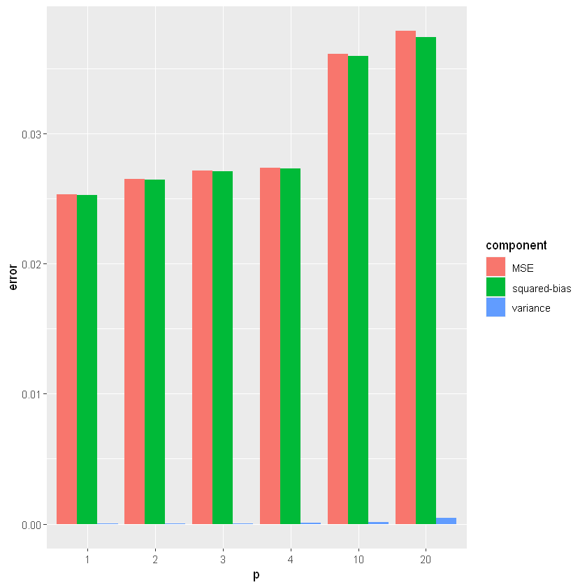

```r
lm_histo <- ggplot(out_lm, aes(fill=component, y=error, x=p)) +
  geom_bar(position="dodge", stat="identity") +
  scale_x_discrete(limits = c("p = 1","p = 2","p = 3","p = 4","p = 10","p = 20"), labels=puse)
lm_histo
```

### KNN regression

[figure not shown]

```r
knn_plot <- ggplot(
          out_knn,
          aes(x=log(K), y=error, col=component)
        ) +
        geom_line() +
        geom_point(size=1) +
        facet_grid(. ~ factor(x = p, levels = c("p = 1","p = 2","p = 3","p = 4","p = 10","p = 20"))
        ) +
        labs(x="log(1/K)", y="Error")
knn_plot
```

### Regression summary

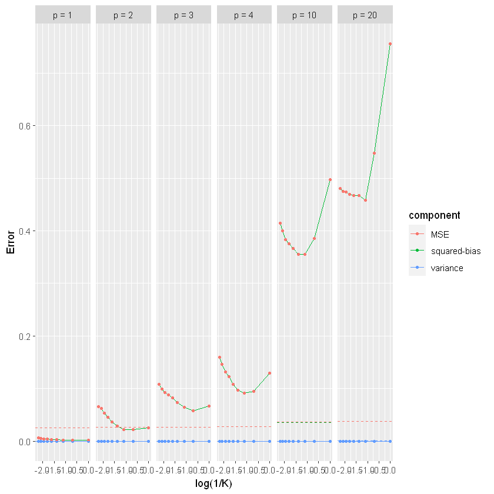

```r
summary_plot <- ggplot(
          out_knn,
          aes(x=log(K), y=error, col=component)
        ) +
        geom_line() +
        geom_point(size=1) +
        geom_hline(
          data = out_lm,
          aes(yintercept = error, col = component),
          linetype="dashed"
        ) +
        facet_grid(. ~ factor(x = p, levels = c("p = 1","p = 2","p = 3","p = 4","p = 10","p = 20"))
        ) +
        labs(x="log(1/K)", y="Error")
summary_plot
```

```r
# Additional Coding

library(FNN)
library(ggplot2)

rm(list=ls())
ntrain <- 50 # Training
ntest <- 500 # Testing
nrep <- 100 # repeat 100 times
p <- 20
puse <- c(1, 2, 3, 4, 10, 20) # number of predictors
k <- c(1:9)

sigma <- 0.025

Xtrain <- matrix(runif(ntrain * p, -1, 1), ntrain, p)
Xtest <- matrix(runif(ntest * p, -1, 1), ntest, p)
y0 <- sin(2 * Xtrain[, 1]) # Only the first predictor is related to y
ytest <- sin(2 *  Xtest[, 1])

out_knn <- data.frame() # Output results
out_lm <- data.frame()

for(i in 1:length(puse)){
  yhat_lm <- matrix(0, ntest, nrep)
  yhat_knn <- replicate(length(k), matrix(0, ntest, nrep))

  for(l in 1:nrep){
    df_train <- data.frame(x=Xtrain[,1:puse[i]])
    y <- y0 + rnorm(ntrain, 0, sigma)

    ######### DO: fit linear regression using lm funciton, assign predicted value to yhat_lm[,l] #########
    fit_lm <- lm(y ~ ., data = df_train)
    testdata = data.frame(x=Xtest[, 1:puse[i]])
    yhat_lm[, l] <- predict(fit_lm, newdata=testdata) # Predicted value by lm

    for(j in 1:length(k)){
      ######### DO: fit knn using knn.reg funciton, assign predicted value to yhat_knn[, l, j] #########
      fit_knn <- knn.reg(
        train = df_train,
        y = y,
        test = testdata,
        k = j,
      )
      yhat_knn[, l, j] <- fit_knn$pred # Predicted value by knn.reg
    }
  #  cat(i, "-th p, ", l, "-th repitition finished. \n")
  }

  ######### DO: compute bias and variance of linear regression #########

  # Compute mean of predicted values
  ybar_lm <- rowMeans(yhat_lm) # E(f^hat)

  # Compute bias^2
  biasSQ_lm <- mean((ytest - ybar_lm)^2) # E[ (f - E(f^hat))^2 ]

  # Compute variance
  variance_lm <- mean((ybar_lm - yhat_lm)^2)# E[ (E(f^hat) - f^hat)^2 ]

  # Compute total MSE
  err_lm <- biasSQ_lm + variance_lm
  #
  out_lm <- rbind(out_lm, data.frame(error = biasSQ_lm, component = "squared-bias", p = paste0("p = ", puse[i])))
  out_lm <- rbind(out_lm, data.frame(error = variance_lm, component = "variance", p = paste0("p = ", puse[i])))
  out_lm <- rbind(out_lm, data.frame(error = err_lm, component = "MSE", p = paste0("p = ", puse[i])))


  ######### DO: compute bias and variance of knn regression #########

  # Compute mean of predicted values
  ybar_knn <- colMeans(aperm(yhat_knn, c(2,1,3)), dims=1)# E(f^hat)

  # Compute bias^2
  biasSQ_knn <- colMeans((ybar_knn - ytest)^2) # E[ (f - E(f^hat))^2 ]

  # Compute variance
  variance_knn <- c() # E[ (E(f^hat) - f^hat)^2 ]
  for(j in 1:length(k)){
    variance_knn <- append(variance_knn, mean(ybar_knn[,j] - yhat_knn[,,j]))
  }

  # Compute total MSE
  err_knn <- variance_knn + biasSQ_knn

  out_knn <- rbind(out_knn, data.frame(error = biasSQ_knn, component = "squared-bias", K = 1/k,p = paste0("p = ", puse[i])))
  out_knn <- rbind(out_knn, data.frame(error = variance_knn, component = "variance", K = 1/k, p = paste0("p = ", puse[i])))
  out_knn <- rbind(out_knn, data.frame(error = err_knn, component = "MSE", K = 1/k, p = paste0("p = ", puse[i])))


  cat(i, "-th p, ", "-th repitition finished. \n")

}

## Plots

### Linear Regression

lm_histo <- ggplot(out_lm, aes(fill=component, y=error, x=p)) +
  geom_bar(position="dodge", stat="identity") +
  scale_x_discrete(limits = c("p = 1","p = 2","p = 3","p = 4","p = 10","p = 20"), labels=puse)
lm_histo

### KNN regression

knn_plot <- ggplot(
          out_knn,
          aes(x=log(K), y=error, col=component)
        ) +
        geom_line() +
        geom_point(size=1) +
        facet_grid(. ~ factor(x = p, levels = c("p = 1","p = 2","p = 3","p = 4","p = 10","p = 20"))
        ) +
        labs(x="log(1/K)", y="Error")
knn_plot

### Regression summary

summary_plot <- ggplot(
          out_knn,
          aes(x=log(K), y=error, col=component)
        ) +
        geom_line() +
        geom_point(size=1) +
        geom_hline(
          data = out_lm,
          aes(yintercept = error, col = component),
          linetype="dashed"
        ) +
        facet_grid(. ~ factor(x = p, levels = c("p = 1","p = 2","p = 3","p = 4","p = 10","p = 20"))
        ) +
        labs(x="log(1/K)", y="Error")
summary_plot
```